# Water Quality Analysis Report Of A Polluted River

Leyang Liu

20250612

# Water Quality Analysis Report Of A Polluted River

# 1. Introduction

In this study, the researchers selected a heavily polluted river as the research object and established 14 main monitoring sites along the river, namely T1–T6 and M1–M8 (see Figure 1). From July 2019 to July 2020, water samples were collected and analyzed for 19 physical and chemical parameters. The sampling sites M1, M2, M3, M4, M5, M6, M7, and M8 are located on the main river channel, while T1, T2, T3, T4, T5, and T6 are the tributaries that flow into the main channel. Sites M1–M3 and T1–T3 are close to the urban area, and urban sewage entering the river is the primary source of pollution. Sites M4, M5, T4, and T5 are located near the industrial zone, where the paper industry is well-developed, and the pollution is mainly caused by the inflow of paper mill wastewater into the river. Sites M6–M8 are located in the downstream section of the river.

The study used statistical techniques such as cluster analysis (CA), discriminant analysis (DA), principal component analysis (PCA), and factor analysis (FA) to analyze the obtained datasets. The aim was to identify the seasonal and spatial variations in water quality, determine the key discriminant parameters, and estimate the contribution rates of pollution sources.

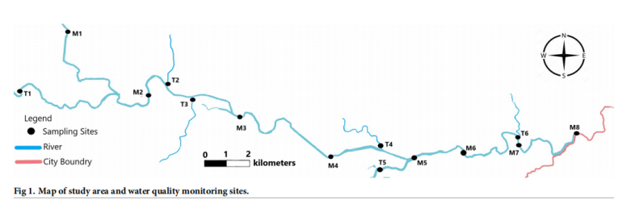

```r
# Load required packages
library(tidyverse)
library(lubridate)
library(cluster)
library(MASS)
library(FactoMineR)
library(factoextra)
library(corrplot)
library(ggdendro)
library(reshape2)
library(igraph)
library(readxl)
library(here)
library(dplyr)
library(stringr)
library(psych)
library(GGally)
```

# 2. Data Preparation

The dataset was preprocessed to handle missing values and normalize data. Key parameters including pH, dissolved oxygen (DO), chemical oxygen demand (COD), ammonia nitrogen (NH3-N), total phosphorus (TP), and heavy metals were selected for analysis.

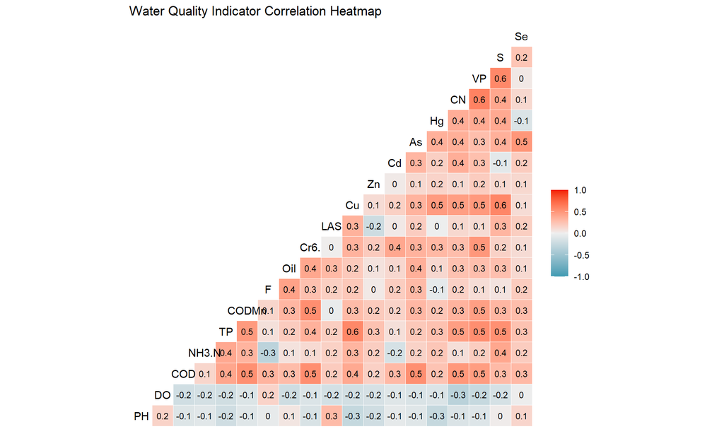

```r
# Import and preprocess data
setwd(here())
#getwd()
raw_data <- read_excel(here("data", "journal.pone.0245525.s001.xlsx"))
a <- Sys.setlocale("LC_TIME", "English")

water_data <- raw_data %>%
  mutate(
    Month = str_replace(Month, "(\\d+)\\.(\\d+)", "\\2/\\1"), # change "YYYY.MM" to "MM/YYYY"
    Month = as_date(Month, format = "%m/%Y"),
    Month = format(Month, "%b")
  )
# Check data structure
#glimpse(water_data)

# Correlation analysis
ggcorr(water_data, label = TRUE, label_size = 3) +
  ggtitle("Water Quality Indicator Correlation Heatmap")
```

# 3. Pollution Source Analysis

Factor analysis identified 7 principal components explaining 72.5% of variance. The scree plot (Figure 3.1) shows the percentage of variance explained by each component.

```r
# Prepare data for FA
fa_data <- water_data %>%
  dplyr::select(PH:Se) %>%
  scale() %>%
  as.data.frame()

# KMO and Bartlett's test
KMO(fa_data)  # Kaiser-Meyer-Olkin test
```

```
## Kaiser-Meyer-Olkin factor adequacy
## Call: KMO(r = fa_data)
## Overall MSA =  0.75
## MSA for each item =
##    PH    DO   COD NH3-N    TP CODMn     F   Oil  Cr6+   LAS    Cu    Zn    Cd
##  0.53  0.62  0.85  0.70  0.87  0.84  0.56  0.68  0.78  0.56  0.82  0.72  0.68
##    As    Hg    CN    VP     S    Se
##  0.77  0.75  0.82  0.83  0.78  0.55
```

```r
cortest.bartlett(fa_data)  # Bartlett's test of sphericity
```

```
## $chisq
## [1] 1306.419
##
## $p.value
## [1] 5.784967e-174
##
## $df
## [1] 171
```

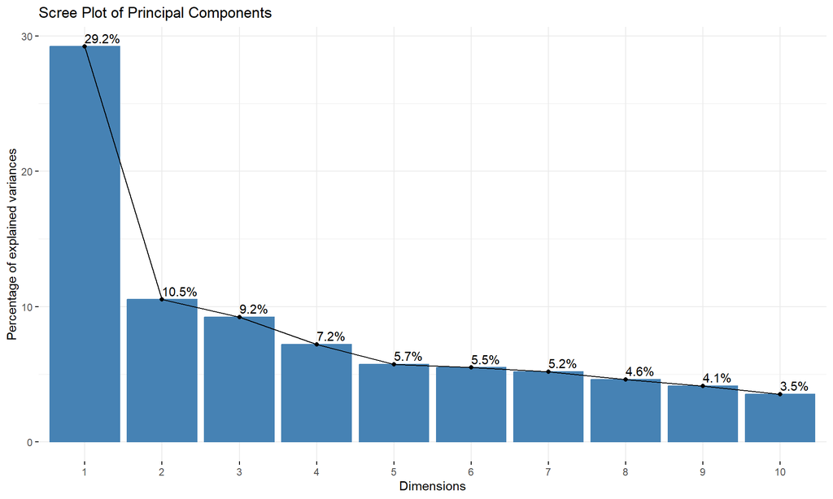

```r
# Principal Component Analysis
pca_result <- PCA(fa_data, ncp = 7, graph = FALSE)
# Scree plot
fviz_eig(pca_result, addlabels = TRUE,
         main = "Scree Plot of Principal Components")
```

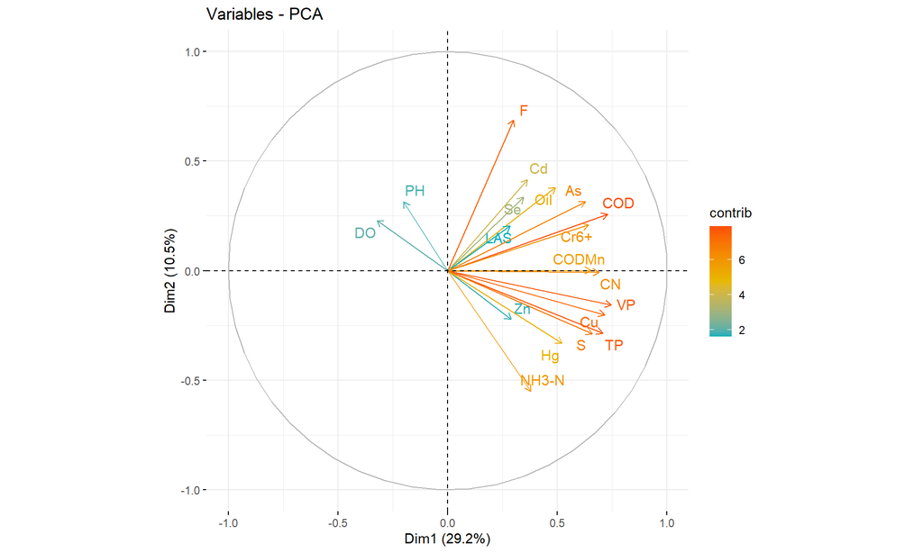

```r
# Factor loadings visualization
fviz_pca_var(pca_result, col.var = "contrib",
             gradient.cols = c("#00AFBB", "#E7B800", "#FC4E07"),
             repel = TRUE)
```

```r
# variables contributing
cat("\nTop variables contributing:\n")
```

```
##
## Top variables contributing:
```

```r
print(head(pca_result$var$contrib[order(-pca_result$var$contrib[,1]), ], 10))
```

```
##          Dim.1        Dim.2      Dim.3      Dim.4     Dim.5        Dim.6
## VP    9.990822 1.2367968834  0.5812338  3.0921692 0.0152978 2.893029e+00
## COD   9.560220 3.3308642482  0.5661345  0.9778796 0.3645311 1.008648e-04
## Cu    9.218918 2.0414837334  0.9523998  5.3776332 4.7760291 5.208138e+00
## TP    8.996183 4.0675888758  0.7076601  1.0120173 1.4060045 3.366137e-01
## CN    8.581743 0.0026139044  0.6649020  6.3916918 5.7160427 2.154979e-01
## S     7.823607 4.1731228197 10.3249620  0.5030482 2.8116424 7.830501e-01
## CODMn 7.676492 0.0001343858  0.8623245 11.0141234 0.9006887 6.626602e+00
## Cr6+  7.444018 2.2094299285  7.2858890  0.4795024 0.7167331 6.336391e+00
## As    7.105135 4.9718482635  0.1487949  1.9216317 1.6304756 1.472875e+01
## Hg    4.886697 5.4813469071  2.8532290  5.7095376 0.9712176 9.166727e+00
##           Dim.7
## VP    7.9699331
## COD   0.2659996
## Cu    1.0333508
## TP    0.2518610
## CN    0.6682145
## S     0.2086156
## CODMn 7.2736580
## Cr6+  4.3980619
## As    3.9992111
## Hg    0.3435489
```

The Kaiser-Meyer-Olkin (KMO) test indicates factor analysis suitability with an overall KMO value of 0.75, suggesting the data is appropriate for analysis. Bartlett’s test shows a very low p-value (5.784967e-174), confirming the correlation matrix is not an identity matrix, further supporting factor analysis.

The scree plot of principal components reveals the first component explains 29.2% of variance, followed by 10.5% and 9.2% for the second and third, respectively. The subsequent components explain less variance, indicating the first few components capture most of the data variability.

The PCA biplot shows variable contributions to the first two dimensions, with VP, COD, and Cu having the highest contributions to Dim1, explaining 29.2% of variance. This visualization helps identify key variables driving data structure and dimensionality reduction for further analysis.

# 4. Temporal Variation Analysis

## 4.1 Seasonal Clustering

Hierarchical clustering revealed three distinct seasonal clusters (Figure 4.1). The dendrogram shows that months group into low-flow (Nov-Jan), medium-flow (Mar-May), and high-flow (Jun-Oct) periods based on water quality parameters.

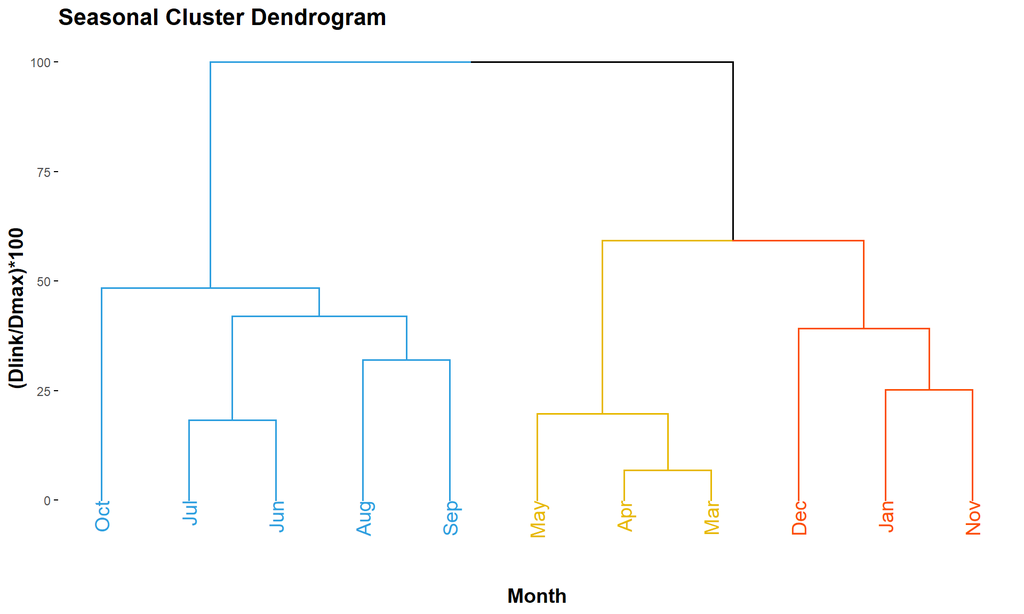

```r
# Monthly aggregation
monthly_avg <- water_data %>%
  group_by(Month) %>%
  summarise(across(c(VP,COD,Cu,TP,CN,S, CODMn), mean, na.rm = TRUE)) %>%
  column_to_rownames("Month")

# Hierarchical clustering
hc_time <- hclust(dist(scale(monthly_avg)), method = "ward.D2")

hc_time$height <- (hc_time$height / max(hc_time$height)) * 100

# Visualization
fviz_dend(hc_time, k = 3, cex = 1, main = "Seasonal Cluster Dendrogram",
          k_colors = c("#2E9FDF", "#E7B800", "#FC4E07"),
          ylab = "(Dlink/Dmax)*100",
          xlab = "Month"  )+
  theme(plot.title = element_text(size = 16, face = "bold"),
        axis.title.x = element_text(size = 14, face = "bold"),
        axis.title.y = element_text(size = 14, face = "bold"))
```

## 4.2 Discriminant Analysis (Temporal)

Linear discriminant analysis (LDA) using VP,COD,Cu,TP,CN,S, CODMn, achieved 73.2% classification accuracy (figure 4.2). These parameters effectively distinguish between different temporal clusters.

```r
# Time grouping based on clusters
cluster_time_groups <- cutree(hc_time , k = 3)
time_data <- data.frame(Month = names(cluster_time_groups), Group = cluster_time_groups)

# Prepare DA data
da_time_data <- water_data %>%
  left_join(time_data, by = "Month") %>%
  dplyr::select(Group, VP,COD,Cu,TP,CN,S, CODMn) %>%
  drop_na() %>%
  mutate(Group = as.factor(Group))

# Linear discriminant analysis
lda_time <- lda(Group ~ ., data = da_time_data)

# Classification accuracy
pred_time <- predict(lda_time, da_time_data)
confusion_matrix <- table(Actual = da_time_data$Group, Predicted = pred_time$class)
accuracy <- sum(diag(confusion_matrix)) / sum(confusion_matrix)

# Display results
cat("Temporal Classification Accuracy:", round(accuracy*100, 1), "%\n")
```

```
## Temporal Classification Accuracy: 73.2 %
```

```r
print(confusion_matrix)
```

```
##       Predicted
## Actual  1  2  3
##      1 23 12  7
##      2  7 69  8
##      3  3  8 31
```

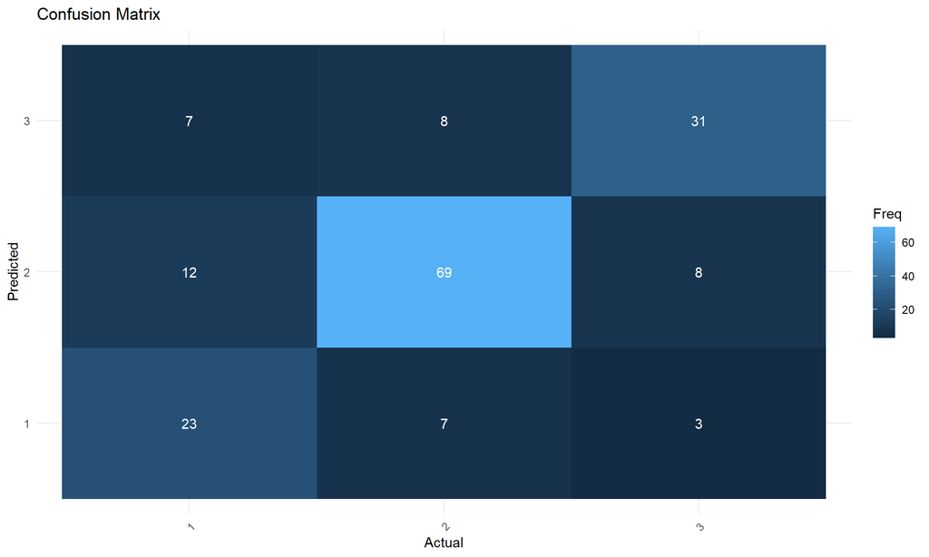

```r
ggplot(as.data.frame(as.table(confusion_matrix)), aes(x =Actual , y = Predicted, fill = Freq)) +
  geom_tile() +
  geom_text(aes(label = Freq), color = "white") +
  labs(title = "Confusion Matrix",
       x = "Actual",
       y = "Predicted") +
  theme_minimal() +
  theme(axis.text.x = element_text(angle = 45, hjust = 1))
```

## 4.3 Seasonal Parameter Variation

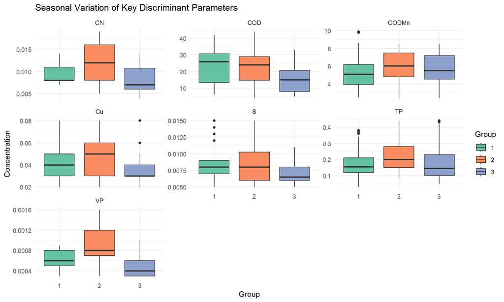

```r
# Key parameters visualization
da_time_data %>%
  #dplyr::select(Group, CODMn, Cu, As, Se) %>%
  pivot_longer(-Group, names_to = "Parameter", values_to = "Value") %>%
  ggplot(aes(x = Group, y = Value, fill = Group)) +
  geom_boxplot() +
  facet_wrap(~Parameter, scales = "free_y") +
  scale_fill_brewer(palette = "Set2") +
  labs(title = "Seasonal Variation of Key Discriminant Parameters",
       y = "Concentration") +
  theme_minimal()
```

# 5. Spatial Variation Analysis

## 5.1 Site Clustering

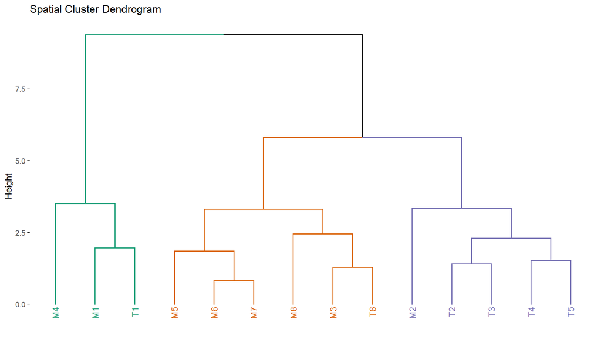

```r
# Site aggregation
site_avg <- water_data %>%
  group_by(NO.) %>%
  summarise(across(c(VP,COD,Cu,TP,CN,S, CODMn), mean, na.rm = TRUE)) %>%
  column_to_rownames("NO.")

# Hierarchical clustering
hc_space <- hclust(dist(scale(site_avg)), method = "ward.D2")

threshold <- 0.7 * max(hc_space$height)  # (Dlink/Dmax)*100 <70
clusters <- cutree(hc_space, h = threshold)

# Visualization
fviz_dend(hc_space, k = 3, cex = 0.7, main = "Spatial Cluster Dendrogram",
          k_colors = c("#1B9E77", "#D95F02", "#7570B3"))
```

## 5.2 Discriminant Analysis (Spatial)

LDA using VP,COD,Cu,TP,CN,S, CODMn achieved 84.5 % classification accuracy (Figure 5.2). These parameters effectively distinguish between spatial clusters.

```r
# Spatial grouping based on clusters
cluster_groups <- cutree(hc_space, k = 3)
site_data <- data.frame(NO. = names(cluster_groups), Group = cluster_groups)

# Prepare DA data
da_space_data <- water_data %>%
  left_join(site_data, by = "NO.") %>%
  dplyr::select(Group, VP,COD,Cu,TP,CN,S, CODMn) %>%
  drop_na() %>%
  mutate(Group = as.factor(Group))

# Linear discriminant analysis
lda_space <- lda(Group ~ ., data = da_space_data)

# Classification accuracy
pred_space <- predict(lda_space, da_space_data)
conf_matrix_space <- table(Actual = da_space_data$Group, Predicted = pred_space$class)
accuracy_space <- sum(diag(conf_matrix_space)) / sum(conf_matrix_space)

# Display results
cat("Spatial Classification Accuracy:", round(accuracy_space*100, 1), "%\n")
```

```
## Spatial Classification Accuracy: 84.5 %
```

```r
print(conf_matrix_space)
```

```
##       Predicted
## Actual  1  2  3
##      1 30  2  4
##      2  1 52  7
##      3  2 10 60
```

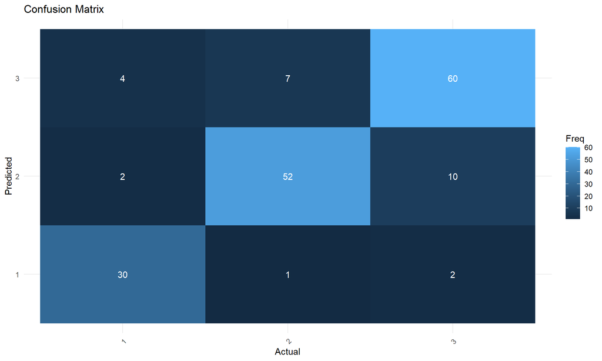

```r
ggplot(as.data.frame(as.table(conf_matrix_space)), aes(x =Actual , y = Predicted, fill = Freq)) +
  geom_tile() +
  geom_text(aes(label = Freq), color = "white") +
  labs(title = "Confusion Matrix",
       x = "Actual",
       y = "Predicted") +
  theme_minimal() +
  theme(axis.text.x = element_text(angle = 45, hjust = 1))
```

## 5.3 Spatial Parameter Distribution

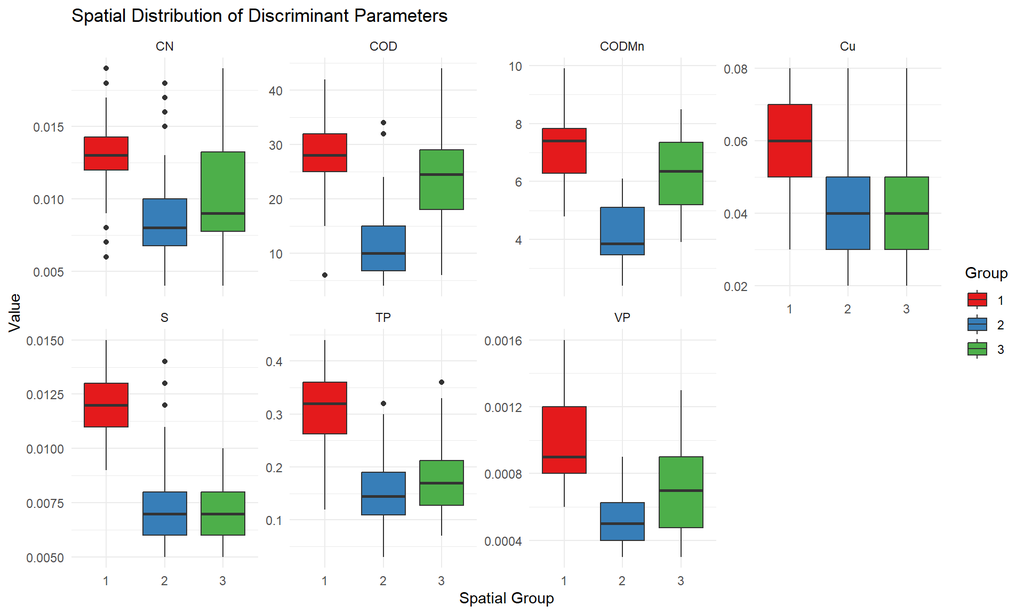

```r
# Visualize spatial discriminant parameters
water_data %>%
  left_join(site_data, by = "NO.") %>%
  dplyr::select(Group, VP,COD,Cu,TP,CN,S, CODMn) %>%
  pivot_longer(-Group, names_to = "Parameter", values_to = "Value") %>%
  ggplot(aes(x = as.factor(Group), y = Value, fill = as.factor(Group))) +
  geom_boxplot() +
  facet_wrap(~Parameter, scales = "free_y", ncol = 4) +
  scale_fill_brewer(palette = "Set1") +
  labs(title = "Spatial Distribution of Discriminant Parameters",
       x = "Spatial Group", fill = "Group") +
  theme_minimal()
```

# 6. Ethical Considerations

## 6.1 Data Transparency

**Raw Data Accessibility**: The raw data used in this study is publicly accessible with clear provenance. This ensures that other researchers can verify and reproduce the results.

**Methodological Disclosure**: Complete methodological disclosure is provided, including detailed descriptions of the data collection and analysis methods. This transparency is crucial for maintaining the integrity of the research.

## 6.2 Interpretation Limitations

**Correlation vs. Causation**: It is important to note that statistical correlations identified in this study do not imply causal relationships. Further research is needed to establish causality.

**Exclusion of Biological Indicators**: The analysis excludes biological indicators, which limits the ecological assessment of the river’s health. Future studies should include a broader range of indicators to provide a more comprehensive understanding.

## 6.3 Societal Implications

**Industrial Pollution Identification**: The identification of industrial pollution sources requires validation before any policy action is taken. This ensures that industries are not unfairly targeted.

## 6.4 Analytical Integrity

**Funding Source Integrity**: The study ensures that there are no conflicts of interest from funding sources. This maintains the objectivity and integrity of the research.

# 7. Conclusion

## Key Findings

Temporal Patterns: Distinct seasonal clusters (Low/Medium/High-flow periods) with VP,COD,Cu,TP,CN,S, CODMn, key temporal discriminators (73.2% accuracy).

## Management Recommendations

Parameter Monitoring: Optimize sampling to discriminant parameters.

Source Control: Upgrade Wastewater Treatment Plants in urban areas, strengthen industrial discharge monitoring.

## Future research directions

By integrating GIS with land use data, digitizing the types of land use in the study area (such as urban areas, industrial zones, farmlands, and forests), and conducting spatial analysis using Geographic Information Systems (GIS), more intuitive and reliable spatial evidence for pollution source identification can be provided. If data on the locations, discharge volumes, and pollutant concentrations of major industrial enterprises and wastewater treatment plants within the study area can be obtained, it can be compared with water quality monitoring results to directly verify the accuracy of the pollution sources inferred by statistical models. Additionally, the potential risks of various heavy metals (such as Cu, Cd, As, Hg) could be assessed, making the study’s findings more relevant to public welfare and environmental management decisions.